# Ranking Methods

November 14, 2014

## Outline

1. Motivation
2. Ranking Methods
3. SVM
4. Application to ranking NCAA football teams

## Motivation

### Why should we care about ranking?

## Why care about about ranking?

[figure not shown]

## Ranking Methods

## Ranking Methods

### Problem setup

- We have \(n\) items/objects we are interested in ranking
- \(\pmb{y}=(y_1, \dots, y_n)\) is a vector of ranks; a permutation of the of the numbers \(\{1,2,\dots,n\}\)
  - i.e. \(y_i=j\), means that object \(i\) is ranked in the \(j\)-th place.
- \(\pmb{x_i}\) is a set of features associated with object \(i\)
- In some situations we may have observed rankings as well
- Our goal is to determine which features are important for modeling the rankings, or determine an ideal global ranking.

## Ranking Methods

### **Probability Models:**

- Order statistics
  - e.g. Bradley-Terry, Plackett-Luce, Rank ordered logit, Multinomial logit, Probit
- Distance based
  - e.g. Mallows

### **Algorithmic Models:**

- "Learning to Rank"
  - e.g. OC SVM, Ranking SVM, RankBoost, RankNet, ListNet, AdaRank, SVM MAP

## Ranking Methods

### Evaluation

| Actual Ranking | Predicted Ranking 1 | Predicted Ranking 2 |
| --- | --- | --- |
| 1 | 1 | 2 |
| 2 | 2 | 1 |
| 3 | 4 | 3 |
| 4 | 3 | 4 |

### Common loss functions / evaluation measures:

- MAP
- Kendall's \(\tau\)
- Discounted Cumalitive Gain (DCG) & Normalized DCG

## Review

### Support Vector Machines

## Support Vector Classifier

### Notation

- \(y_i = -1\) or \(1\)
- \(x_{i1}, \dots, x_{ip}\) are features for observation \(i\), \(\,i=1,\dots,n\)

### A hyperplane:

- \(\{ x: f(x)=x^T\beta+\beta_0=0 \}\), where \(\sum \beta_j^2 = 1\)

### The classification rule:

- \(G(x) = sign [x^T\beta+\beta_0 ]\)

## Support Vector Classifier

We want to find the hyperplane that has the largest margin between training points of different classes.

That is, \[ \underset{\beta_0, \beta, \|\beta\|=1}{max} M \] subject to \[ y_i(x_i^T\beta+\beta_0)\geq M, \, i=1,\dots,n \]

## Support Vector Classifier

### Separating hyperplane with largest margin

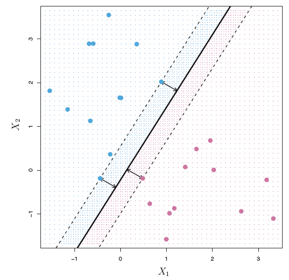

## Support Vector Classifier

- Finding a separating hyperplane is not always possible, so we allow some points to be on the wrong side of the hyperplane.
- Now the optimization problem can be written as \[ \underset{\| \beta \|}{min}\, \text{ subject to } \,y_i(x_i^T\beta+\beta_0)\geq 1-\epsilon_i \] for all \(i\) and \[ \sum \epsilon_i \leq \text{constant}, \text{ and } \epsilon_i \geq 0 \]
- \(\epsilon_i\) are slack variables

## The Support Vector Machine

- The feature space can be expanding by taking inner products of the feature, etc.
- SVM extends the support vector classifier by enlarging the feature space through the use of kernels
  - Most common kernels are polynomials and radial basis functions
- Polynomial kernel: \(K(x_i, x_{i'})= \left( 1 + \sum_{j=1}^{p}x_{ij}x_{i'j} \right)^d\)
- Radial kernel: \(K(x_i, x_{i'})= exp\{ -\gamma \sum_{j=1}^{p}(x_{ij}-x_{i'j})^2 \}\)

## The Support Vector Machine

### Comparison to regularization

- The optimization can again be reformulated as: \[ \underset{\beta_0,\beta}{min} \sum_{i=1}^{n}[1-y_if(x_i)]_{+} + \frac{\lambda}{2} \|\beta \|^2 \]
- Loss + Penalty
- Hinge loss function
- \(\lambda = 1/C\)

## A simulated example

## Simulated Example

### Simulated Rankings and Features

\[ \begin{pmatrix} y_1 \\ y_2 \\ y_3 \\ y_4 \\ y_5 \end{pmatrix} = \begin{pmatrix} 1 \\ 2 \\ 3 \\ 4 \\ 5 \end{pmatrix} \; \text{and} \quad \pmb{X} = \begin{pmatrix} \pmb{x_1}^T \\ \pmb{x_2}^T \\ \pmb{x_3}^T \\ \pmb{x_4}^T \\ \pmb{x_5}^T \\ \end{pmatrix}= \begin{pmatrix} x_{11} & x_{12} \\ x_{21} & x_{22} \\ x_{31} & x_{32} \\ x_{41} & x_{42} \\ x_{51} & x_{52} \\ \end{pmatrix} \]

## Simulated Example

### Rankings over the feature space

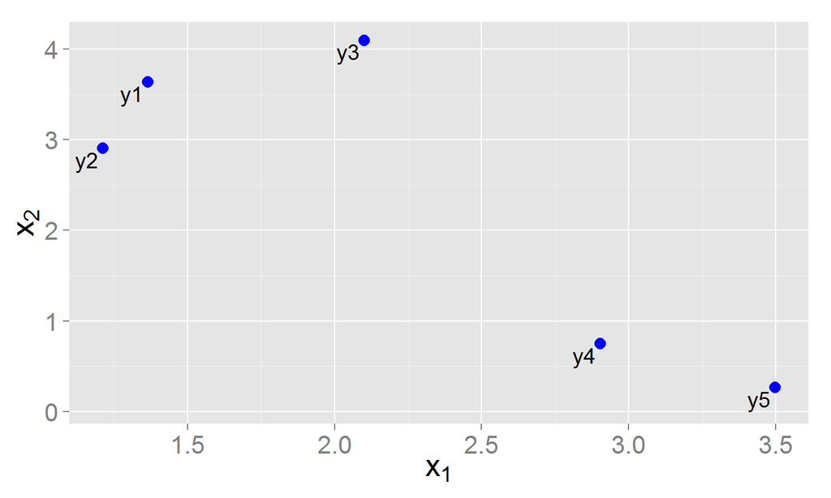

## Simulated Example

### Transformation to Pairwise Classification

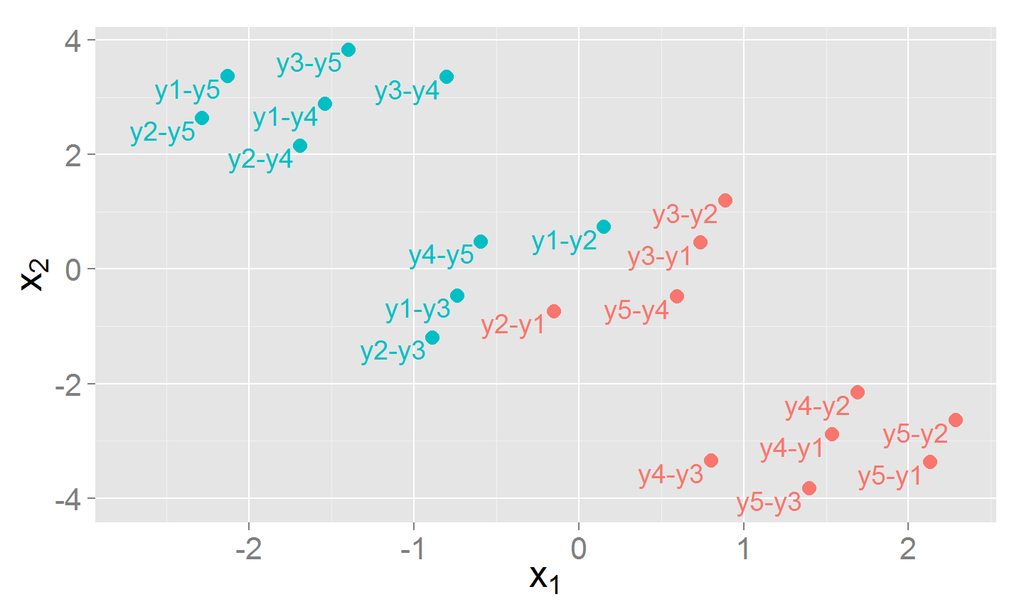

## Simulated Example

### Train a SVM classifier

```r
## Specify 'cost' parameter and fit SVM
svmfit   <- svm(class~x1+x2, data=df, kernel='linear', cost=10)

## Or use cross-validation to tune for the 'cost' parameter
tune.out <- tune(svm,class~x1+x2, data=df, kernel='linear',
                 ranges=list(cost=10^(-4:4)))
best.mod <- tune.out$best.model
```

## Simulated Example

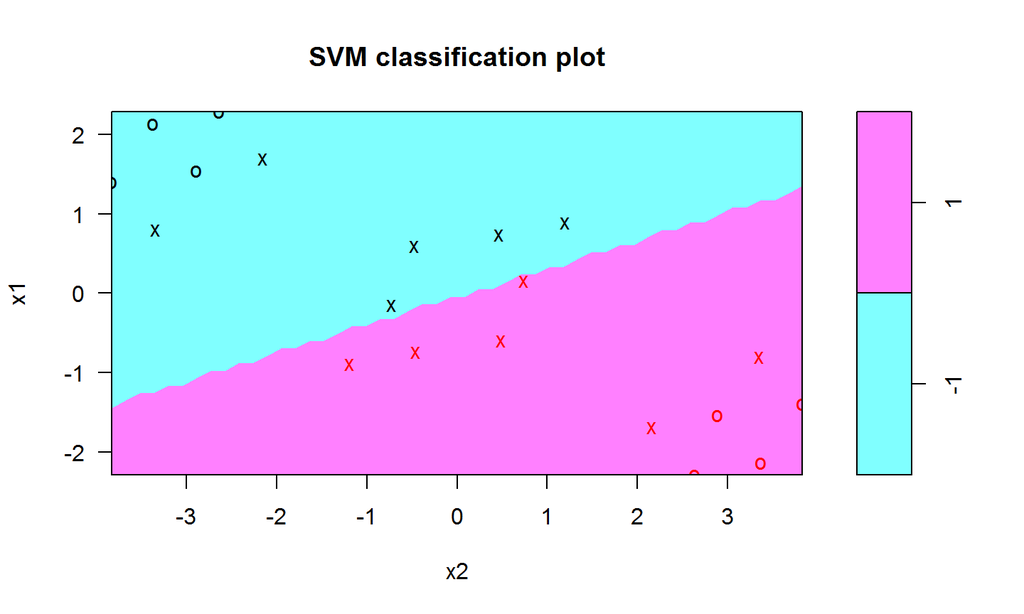

```r
plot(best.mod, df)
```

## Simulated Example

- Generate testing data:  
  \(y_1^*,y_2^*,y_3^*,y_4^*,y_5^*\) and \(\pmb{x^*_1}^T,\pmb{x^*_2}^T,\pmb{x^*_3}^T,\pmb{x^*_4}^T ,\pmb{x^*_5}^T\)
- Use fitted SVM model to get *decision values* for each observation in the testing data
  - i.e., \(d_i = \widehat \beta_0 + \widehat \beta_1 x_{i1} + \widehat \beta_2 x_{i2}\)
- Rank testing observations according to the decision values

## Simulated Example

### Testing data

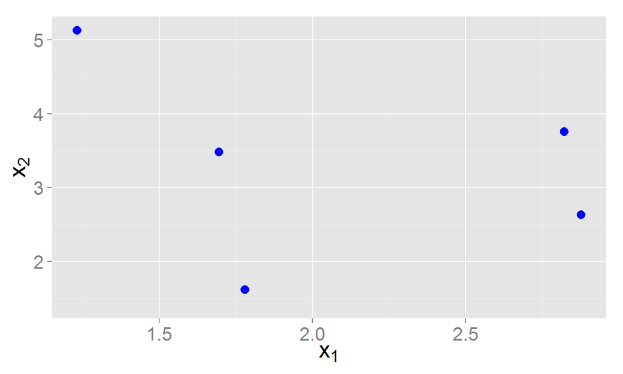

## Simulated Example

### Testing data

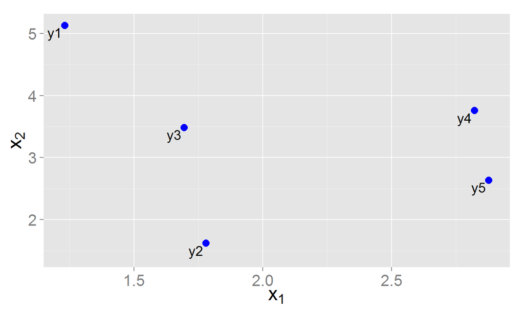

## Simulated Example

### Ranking Testing data

| Actual | Predicted |
| --- | --- |
| 1 | 1 |
| 2 | 3 |
| 3 | 2 |
| 4 | 4 |
| 5 | 5 |

**Kendall's \(\tau\) = 0.8**

## An application

### Ranking 2014 NCAA Football Teams

## Ranking NCAA Football Teams

### The ranking problem

- How to rank the top 25 teams?
- Hard problem
  - 128 teams in the FBS
  - Each team only plays 10-14 games in a season
  - Only a few games (if any) against other highly ranked teams
  - Lots of variables

## Ranking NCAA Football Teams

### The data

- Collected from sports-reference.com
- Use the AP Top 25 Poll as the "ideal" ranking to model
- Training rankings = 2013 AP Poll as of Week 12
- Testing rankings = 2014 AP Poll as of Week 12 (this week)
- Features:
  - Offense & Defense stats: Points scored (Avg), Passing %, Rushing Yds (Avg), Total Yds (Avg), Turnover (Avg), Penalty Yds (Avg)
  - Conference,
  - Win %
  - Wins & losses against other ranked teams

## Ranking NCAA Football Teams

### Ranking SVM

| Rank | Actual | Predicted |  | Rank | Actual | Predicted |
| --- | --- | --- | --- | --- | --- | --- |
| 1. | Mississippi State | Mississippi State |  | 9. | Auburn | Arizona State |
| 2. | Florida State | Oregon |  | 10. | Mississippi | Nebraska |
| 3. | Oregon | Florida State |  | 11. | Nebraska | Texas Christian |
| 4. | Alabama | Mississippi |  | 12. | Michigan State | Auburn |
| 5. | Texas Christian | Marshall |  | 13. | Kansas State | Kansas State |
| 6. | Baylor | Alabama |  | 14. | UCLA | Duke |
| 7. | Arizona State | Ohio State |  | 15. | Notre Dame | UCLA |
| 8. | Ohio State | Baylor |  | 16. | Georgia | Michigan State |

## Ranking NCAA Football Teams

### Ranking with Regression

| Rank | Actual | Predicted |  | Rank | Actual | Predicted |
| --- | --- | --- | --- | --- | --- | --- |
| 1. | Mississippi State | Mississippi State |  | 9. | Auburn | Arizona State |
| 2. | Florida State | Florida State |  | 10. | Mississippi | Louisiana State |
| 3. | Oregon | Alabama |  | 11. | Nebraska | Baylor |
| 4. | Alabama | Oregon |  | 12. | Michigan State | Texas Christian |
| 5. | Texas Christian | Ohio State |  | 13. | Kansas State | Michigan State |
| 6. | Baylor | Nebraska |  | 14. | UCLA | UCLA |
| 7. | Arizona State | Mississippi |  | 15. | Notre Dame | Auburn |
| 8. | Ohio State | Marshall |  | 16. | Georgia | Kansas State |

## Ranking NCAA Football Teams

### How do they compare?

| Method | Kendall's \(\tau\) |
| --- | --- |
| SVM | 0.633 |
| Regression | 0.627 |

### What went wrong?

- Neither method used the group structure of the data
- Ranking SVM was one of the first methods for "learning to rank". Many more advanced methods exist now.